# Practical Machine Learning Coursera Project

Mohammad Azam Khan

November 21, 2015

## Background

Using devices such as Jawbone Up, Nike FuelBand, and Fitbit it is now possible to collect a large amount of data about personal activity relatively inexpensively. These type of devices are part of the quantified self movement - a group of enthusiasts who take measurements about themselves regularly to improve their health, to find patterns in their behavior, or because they are tech geeks. One thing that people regularly do is quantify how much of a particular activity they do, but they rarely quantify how well they do it.

In this project, we will use data from accelerometers on the belt, forearm, arm, and dumbell of 6 participants to select and build an optimal prediction model.

The participants were asked to perform barbell lifts correctly and incorrectly in 5 different ways. More information is available from the website here: http://groupware.les.inf.puc-rio.br/har

## Download the dataset

```r
trainingDatasetFileUrl <- "http://d396qusza40orc.cloudfront.net/predmachlearn/pml-training.csv"
destFile <- "./pml-training.csv"
if(!file.exists(destFile)){
  download.file(trainingDatasetFileUrl, destFile, method = "curl")
}

testingDatasetFileUrl <- "http://d396qusza40orc.cloudfront.net/predmachlearn/pml-testing.csv"
destFile <- "./pml-testing.csv"
if(!file.exists(destFile)){
  download.file(testingDatasetFileUrl, destFile, method = "curl")
}
```

## Reading the data

```r
datasetTraining <- read.csv("./pml-training.csv", header = TRUE)
datasetTesting <- read.csv("./pml-testing.csv", header = TRUE)
```

## Structure of the Training dataset

```r
str(datasetTraining)
```

```
## 'data.frame':    19622 obs. of  160 variables:
##  $ X                       : int  1 2 3 4 5 6 7 8 9 10 ...
##  $ user_name               : Factor w/ 6 levels "adelmo","carlitos",..: 2 2 2 2 2 2 2 2 2 2 ...
##  $ raw_timestamp_part_1    : int  1323084231 1323084231 1323084231 1323084232 1323084232 1323084232 1323084232 1323084232 1323084232 1323084232 ...
##  $ raw_timestamp_part_2    : int  788290 808298 820366 120339 196328 304277 368296 440390 484323 484434 ...
##  $ cvtd_timestamp          : Factor w/ 20 levels "02/12/2011 13:32",..: 9 9 9 9 9 9 9 9 9 9 ...
##  $ new_window              : Factor w/ 2 levels "no","yes": 1 1 1 1 1 1 1 1 1 1 ...
##  $ num_window              : int  11 11 11 12 12 12 12 12 12 12 ...
##  $ roll_belt               : num  1.41 1.41 1.42 1.48 1.48 1.45 1.42 1.42 1.43 1.45 ...
##  $ pitch_belt              : num  8.07 8.07 8.07 8.05 8.07 8.06 8.09 8.13 8.16 8.17 ...
##  $ yaw_belt                : num  -94.4 -94.4 -94.4 -94.4 -94.4 -94.4 -94.4 -94.4 -94.4 -94.4 ...
##  $ total_accel_belt        : int  3 3 3 3 3 3 3 3 3 3 ...
##  $ kurtosis_roll_belt      : Factor w/ 397 levels "","-0.016850",..: 1 1 1 1 1 1 1 1 1 1 ...
##  $ kurtosis_picth_belt     : Factor w/ 317 levels "","-0.021887",..: 1 1 1 1 1 1 1 1 1 1 ...
##  $ kurtosis_yaw_belt       : Factor w/ 2 levels "","#DIV/0!": 1 1 1 1 1 1 1 1 1 1 ...
```

[output cut: 86 more lines]

There are 19622 observations with 160 variables each.

## Creating Tidy dataset

The training dataset contains some invalid values such as NA’s and blanks in some variables (say, var_total_accel_belt). It is better to eliminate such variables with large amount of invalid values be excluded from the model.

```r
summary(datasetTraining$var_total_accel_belt)
```

```
##    Min. 1st Qu.  Median    Mean 3rd Qu.    Max.    NA's
##   0.000   0.100   0.200   0.926   0.300  16.500   19216
```

After excluding the abovementioned variables, it is found that the data has no more invalid values as described by `complete.cases` command. We now have 54 variables, including the variable to be predicted, `classe`.

```r
datasetTrainingTidy <- datasetTraining[, -c(grep("^amplitude|^kurtosis|^skewness|^avg|^cvtd_timestamp|^max|^min|^new_window|^raw_timestamp|^stddev|^var|^user_name|X", names(datasetTraining)))]

paste("Complete Cases: ")
```

```
## [1] "Complete Cases: "
```

```r
table(complete.cases(datasetTrainingTidy))
```

```
##
##  TRUE
## 19622
```

## Splitting the dataset

Given that we have a medium to large sample size, it is decided that the tidy data be further split into two sets, 60% for training and 40% for testing.

```r
library(caret)
set.seed(39)
inTrain <- createDataPartition(y = datasetTrainingTidy$classe, times = 1, p = 0.6, list = FALSE)
dataTidyTrain <- datasetTrainingTidy[inTrain, ]
dataTidyTest <- datasetTrainingTidy[-inTrain, ]
```

## Model Selection

### Model Comparison

1. It is determined that this is a classification problem and the aim of the comparison is to discover which algorithm suits the data better.
2. The RandomForest `rf` and Gradient Boosting `gbm` algorithms are selected for comparison based on the accuracy these algorithms can achieve in classification. In addition, these two models have built-in feature selection as described in the Caret package reference.
3. The Kappa metric is selected as the comparison criteria.
4. To reduce the risk of overfitting, a 10-fold cross validation is employed during model building.

```r
library(randomForest)
set.seed(39)
# k-fold validation - 10-fold validation, use kappa as metric
fitControl <- trainControl(method = "cv", number = 10)
gbmFit <- train(classe~., data = dataTidyTrain, method = "gbm", metric = "Kappa", trControl = fitControl, verbose = FALSE)
rfFit <- train(classe ~., data = dataTidyTrain, method = "rf", metric = "Kappa", trControl = fitControl)
```

### Model Plotting and selection

1. The models are then compared using the `resamples` function from the Caret package.
2. Based on the plot below, it can be determined that the RandomForest algorithm fares better than the Gradient Boosting algorithm for this dataset, achieving a Kappa mean value of 0.996. It can also be seen that the RandomForest algorithm also displays less spread than Gradient Boosting.
3. Therefore, the RandomForest model is selected for this dataset.

```r
library(caret)
library(lattice)
rValues <- resamples(list(rf = rfFit, gbm = gbmFit))
summary(rValues)
```

```
##
## Call:
## summary.resamples(object = rValues)
##
## Models: rf, gbm
## Number of resamples: 10
##
## Accuracy
##       Min. 1st Qu. Median   Mean 3rd Qu.   Max. NA's
## rf  0.9966  0.9966 0.9966 0.9974  0.9981 0.9992    0
## gbm 0.9830  0.9864 0.9873 0.9873  0.9887 0.9915    0
##
## Kappa
##       Min. 1st Qu. Median   Mean 3rd Qu.   Max. NA's
## rf  0.9957  0.9957 0.9957 0.9967  0.9976 0.9989    0
## gbm 0.9785  0.9828 0.9839 0.9839  0.9858 0.9893    0
```

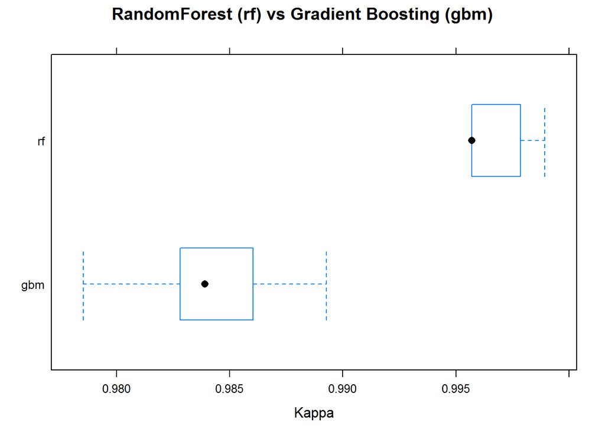

```r
bwplot(rValues, metric = "Kappa", main = "RandomForest (rf) vs Gradient Boosting (gbm)")
```

## Model Validation

1. With the selected RandomForest model, we shall proceed to model validation.
2. The details of the selected model is shown below.

```r
rfFit
```

```
## Random Forest
##
## 11776 samples
##    53 predictor
##     5 classes: 'A', 'B', 'C', 'D', 'E'
##
## No pre-processing
## Resampling: Cross-Validated (10 fold)
## Summary of sample sizes: 10600, 10599, 10599, 10597, 10599, 10599, ...
## Resampling results across tuning parameters:
##
##   mtry  Accuracy   Kappa      Accuracy SD  Kappa SD
##    2    0.9932928  0.9915153  0.002809811  0.003554941
##   27    0.9973678  0.9966704  0.001092211  0.001381577
##   53    0.9933774  0.9916227  0.002931755  0.003708104
##
## Kappa was used to select the optimal model using  the largest value.
## The final value used for the model was mtry = 27.
```

3. We shall be using the `confusionMatrix` function in the Caret package to validate the selected model with the `dataTidyTest` test set. The corresponding statistics and error rates are shown.

```r
confusionMatrix(dataTidyTest$classe, predict(rfFit, dataTidyTest))
```

```
## Confusion Matrix and Statistics
##
##           Reference
## Prediction    A    B    C    D    E
##          A 2231    1    0    0    0
##          B    2 1515    1    0    0
##          C    0    5 1363    0    0
##          D    0    0    9 1269    8
##          E    0    0    0    5 1437
##
## Overall Statistics
##
##                Accuracy : 0.996
##                  95% CI : (0.9944, 0.9973)
##     No Information Rate : 0.2846
##     P-Value [Acc > NIR] : < 2.2e-16
##
##                   Kappa : 0.995
##  Mcnemar's Test P-Value : NA
##
## Statistics by Class:
##
##                      Class: A Class: B Class: C Class: D Class: E
## Sensitivity            0.9991   0.9961   0.9927   0.9961   0.9945
## Specificity            0.9998   0.9995   0.9992   0.9974   0.9992
## Pos Pred Value         0.9996   0.9980   0.9963   0.9868   0.9965
## Neg Pred Value         0.9996   0.9991   0.9985   0.9992   0.9988
## Prevalence             0.2846   0.1939   0.1750   0.1624   0.1842
## Detection Rate         0.2843   0.1931   0.1737   0.1617   0.1832
## Detection Prevalence   0.2845   0.1935   0.1744   0.1639   0.1838
## Balanced Accuracy      0.9995   0.9978   0.9960   0.9967   0.9968
```

4. From the above validation result, it can be determined that the selected Model performs at a Kappa value of 0.995, with an accuracy of 0.996.

## Final Model Testing

Finally, we shall use the selected model to predict the classification of the testing set provided.

```r
results <- predict(rfFit, newdata = datasetTesting)
print(as.data.frame(results))
```

```
##    results
## 1        B
## 2        A
## 3        B
## 4        A
## 5        A
## 6        E
## 7        D
## 8        B
## 9        A
## 10       A
## 11       B
## 12       C
## 13       B
## 14       A
## 15       E
## 16       E
## 17       A
## 18       B
## 19       B
## 20       B
```